# Saving and Loading Models

In this notebook, I'll show you how to save and load models with PyTorch. This is important because you'll often want to load previously trained models to use in making predictions or to continue training on new data.

```python
%matplotlib inline
%config InlineBackend.figure_format = 'retina'

import matplotlib.pyplot as plt

import torch
from torch import nn
from torch import optim
import torch.nn.functional as F
from torchvision import datasets, transforms

import helper
import fc_model
```

```python
# Define a transform to normalize the data
transform = transforms.Compose([transforms.ToTensor(),
                                transforms.Normalize((0.5,), (0.5,))])
# Download and load the training data
trainset = datasets.FashionMNIST('D:/Programming and Courses/Neural Network/Udacity_DeepLearning/Neural Network/Non_Linear/Intro_Pytorch/F_MNIST_data/', download=True, train=True, transform=transform)
trainloader = torch.utils.data.DataLoader(trainset, batch_size=64, shuffle=True)

# Download and load the test data
testset = datasets.FashionMNIST('D:/Programming and Courses/Neural Network/Udacity_DeepLearning/Neural Network/Non_Linear/Intro_Pytorch/F_MNIST_data/', download=True, train=False, transform=transform)
testloader = torch.utils.data.DataLoader(testset, batch_size=64, shuffle=True)
```

Here we can see one of the images.

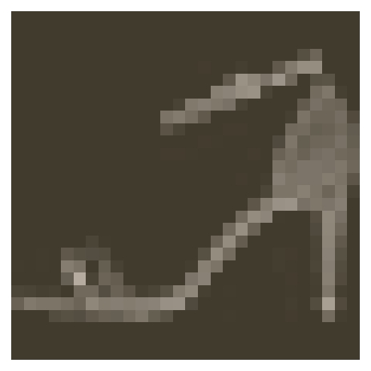

```python
image, label = next(iter(trainloader))
helper.imshow(image[0,:]);
```

# Train a network

To make things more concise here, I moved the model architecture and training code from the last part to a file called `fc_model`. Importing this, we can easily create a fully-connected network with `fc_model.Network`, and train the network using `fc_model.train`. I'll use this model (once it's trained) to demonstrate how we can save and load models.

```python
# Create the network, define the criterion and optimizer

model = fc_model.Network(784, 10, [512, 256, 128])
criterion = nn.NLLLoss()
optimizer = optim.Adam(model.parameters(), lr=0.001)
```

```python
fc_model.train(model, trainloader, testloader, criterion, optimizer, epochs=2)
```

```
Epoch: 1/2..  Training Loss: 1.694..  Test Loss: 0.957..  Test Accuracy: 0.644
Epoch: 1/2..  Training Loss: 1.006..  Test Loss: 0.755..  Test Accuracy: 0.726
Epoch: 1/2..  Training Loss: 0.862..  Test Loss: 0.688..  Test Accuracy: 0.739
Epoch: 1/2..  Training Loss: 0.772..  Test Loss: 0.654..  Test Accuracy: 0.748
Epoch: 1/2..  Training Loss: 0.736..  Test Loss: 0.615..  Test Accuracy: 0.765
Epoch: 1/2..  Training Loss: 0.716..  Test Loss: 0.587..  Test Accuracy: 0.777
Epoch: 1/2..  Training Loss: 0.712..  Test Loss: 0.595..  Test Accuracy: 0.772
Epoch: 1/2..  Training Loss: 0.680..  Test Loss: 0.567..  Test Accuracy: 0.786
Epoch: 1/2..  Training Loss: 0.663..  Test Loss: 0.569..  Test Accuracy: 0.794
Epoch: 1/2..  Training Loss: 0.685..  Test Loss: 0.554..  Test Accuracy: 0.793
Epoch: 1/2..  Training Loss: 0.646..  Test Loss: 0.552..  Test Accuracy: 0.796
Epoch: 1/2..  Training Loss: 0.635..  Test Loss: 0.519..  Test Accuracy: 0.804
Epoch: 1/2..  Training Loss: 0.585..  Test Loss: 0.525..  Test Accuracy: 0.803
Epoch: 1/2..  Training Loss: 0.632..  Test Loss: 0.526..  Test Accuracy: 0.802
Epoch: 1/2..  Training Loss: 0.622..  Test Loss: 0.521..  Test Accuracy: 0.810
Epoch: 1/2..  Training Loss: 0.574..  Test Loss: 0.505..  Test Accuracy: 0.816
Epoch: 1/2..  Training Loss: 0.607..  Test Loss: 0.515..  Test Accuracy: 0.809
Epoch: 1/2..  Training Loss: 0.592..  Test Loss: 0.496..  Test Accuracy: 0.816
Epoch: 1/2..  Training Loss: 0.587..  Test Loss: 0.480..  Test Accuracy: 0.820
Epoch: 1/2..  Training Loss: 0.570..  Test Loss: 0.513..  Test Accuracy: 0.814
Epoch: 1/2..  Training Loss: 0.579..  Test Loss: 0.497..  Test Accuracy: 0.812
Epoch: 1/2..  Training Loss: 0.559..  Test Loss: 0.476..  Test Accuracy: 0.829
Epoch: 1/2..  Training Loss: 0.581..  Test Loss: 0.485..  Test Accuracy: 0.814
Epoch: 2/2..  Training Loss: 0.603..  Test Loss: 0.496..  Test Accuracy: 0.819
Epoch: 2/2..  Training Loss: 0.555..  Test Loss: 0.498..  Test Accuracy: 0.811
Epoch: 2/2..  Training Loss: 0.563..  Test Loss: 0.479..  Test Accuracy: 0.827
Epoch: 2/2..  Training Loss: 0.542..  Test Loss: 0.473..  Test Accuracy: 0.825
Epoch: 2/2..  Training Loss: 0.552..  Test Loss: 0.488..  Test Accuracy: 0.824
Epoch: 2/2..  Training Loss: 0.527..  Test Loss: 0.466..  Test Accuracy: 0.828
Epoch: 2/2..  Training Loss: 0.557..  Test Loss: 0.473..  Test Accuracy: 0.830
Epoch: 2/2..  Training Loss: 0.523..  Test Loss: 0.459..  Test Accuracy: 0.833
Epoch: 2/2..  Training Loss: 0.511..  Test Loss: 0.460..  Test Accuracy: 0.830
Epoch: 2/2..  Training Loss: 0.547..  Test Loss: 0.470..  Test Accuracy: 0.826
Epoch: 2/2..  Training Loss: 0.495..  Test Loss: 0.455..  Test Accuracy: 0.832
Epoch: 2/2..  Training Loss: 0.542..  Test Loss: 0.486..  Test Accuracy: 0.820
Epoch: 2/2..  Training Loss: 0.572..  Test Loss: 0.464..  Test Accuracy: 0.827
Epoch: 2/2..  Training Loss: 0.571..  Test Loss: 0.458..  Test Accuracy: 0.834
Epoch: 2/2..  Training Loss: 0.531..  Test Loss: 0.455..  Test Accuracy: 0.832
Epoch: 2/2..  Training Loss: 0.520..  Test Loss: 0.443..  Test Accuracy: 0.837
Epoch: 2/2..  Training Loss: 0.509..  Test Loss: 0.460..  Test Accuracy: 0.831
Epoch: 2/2..  Training Loss: 0.491..  Test Loss: 0.450..  Test Accuracy: 0.835
Epoch: 2/2..  Training Loss: 0.532..  Test Loss: 0.462..  Test Accuracy: 0.831
Epoch: 2/2..  Training Loss: 0.504..  Test Loss: 0.456..  Test Accuracy: 0.831
Epoch: 2/2..  Training Loss: 0.515..  Test Loss: 0.474..  Test Accuracy: 0.824
Epoch: 2/2..  Training Loss: 0.527..  Test Loss: 0.452..  Test Accuracy: 0.831
Epoch: 2/2..  Training Loss: 0.520..  Test Loss: 0.458..  Test Accuracy: 0.831
```

## Saving and loading networks

As you can imagine, it's impractical to train a network every time you need to use it. Instead, we can save trained networks then load them later to train more or use them for predictions.

The parameters for PyTorch networks are stored in a model's `state_dict`. We can see the state dict contains the weight and bias matrices for each of our layers.

### Print the networks:

```python
print("Our model: \n\n", model, '\n')
print("The state dict keys: \n\n", model.state_dict().keys())
```

```
Our model:

 Network(
  (hidden_layers): ModuleList(
    (0): Linear(in_features=784, out_features=512, bias=True)
    (1): Linear(in_features=512, out_features=256, bias=True)
    (2): Linear(in_features=256, out_features=128, bias=True)
  )
  (output): Linear(in_features=128, out_features=10, bias=True)
  (dropout): Dropout(p=0.5, inplace=False)
)

The state dict keys:

 odict_keys(['hidden_layers.0.weight', 'hidden_layers.0.bias', 'hidden_layers.1.weight', 'hidden_layers.1.bias', 'hidden_layers.2.weight', 'hidden_layers.2.bias', 'output.weight', 'output.bias'])
```

The simplest thing to do is simply save the state dict with `torch.save`. For example, we can save it to a file `'checkpoint.pth'`.

### Save the model

```python
torch.save(model.state_dict(), 'checkpoint.pth')
```

### Load the model

Then we can load the state dict with `torch.load`.

```python
state_dict = torch.load('checkpoint.pth')
print(state_dict.keys())
```

```
odict_keys(['hidden_layers.0.weight', 'hidden_layers.0.bias', 'hidden_layers.1.weight', 'hidden_layers.1.bias', 'hidden_layers.2.weight', 'hidden_layers.2.bias', 'output.weight', 'output.bias'])
```

And to load the state dict in to the network, you do `model.load_state_dict(state_dict)`.

```python
model.load_state_dict(state_dict)
```

```
<All keys matched successfully>
```

Seems pretty straightforward, but as usual it's a bit more complicated. Loading the state dict works only if the model architecture is exactly the same as the checkpoint architecture. If I create a model with a different architecture, this fails.

```python
# Try this
model = fc_model.Network(784, 10, [400, 200, 100])
# This will throw an error because the tensor sizes are wrong!
model.load_state_dict(state_dict)
```

```
---------------------------------------------------------------------------
RuntimeError                              Traceback (most recent call last)
~\AppData\Local\Temp/ipykernel_18264/1721305045.py in <module>
      2 model = fc_model.Network(784, 10, [400, 200, 100])
      3 # This will throw an error because the tensor sizes are wrong!
----> 4 model.load_state_dict(state_dict)

c:\users\khobr\appdata\local\programs\python\python39\lib\site-packages\torch\nn\modules\module.py in load_state_dict(self, state_dict, strict)
   1480
   1481         if len(error_msgs) > 0:
-> 1482             raise RuntimeError('Error(s) in loading state_dict for {}:\n\t{}'.format(
   1483                                self.__class__.__name__, "\n\t".join(error_msgs)))
   1484         return _IncompatibleKeys(missing_keys, unexpected_keys)

RuntimeError: Error(s) in loading state_dict for Network:
	size mismatch for hidden_layers.0.weight: copying a param with shape torch.Size([512, 784]) from checkpoint, the shape in current model is torch.Size([400, 784]).
	size mismatch for hidden_layers.0.bias: copying a param with shape torch.Size([512]) from checkpoint, the shape in current model is torch.Size([400]).
	size mismatch for hidden_layers.1.weight: copying a param with shape torch.Size([256, 512]) from checkpoint, the shape in current model is torch.Size([200, 400]).
	size mismatch for hidden_layers.1.bias: copying a param with shape torch.Size([256]) from checkpoint, the shape in current model is torch.Size([200]).
	size mismatch for hidden_layers.2.weight: copying a param with shape torch.Size([128, 256]) from checkpoint, the shape in current model is torch.Size([100, 200]).
	size mismatch for hidden_layers.2.bias: copying a param with shape torch.Size([128]) from checkpoint, the shape in current model is torch.Size([100]).
	size mismatch for output.weight: copying a param with shape torch.Size([10, 128]) from checkpoint, the shape in current model is torch.Size([10, 100]).
```

This means we need to rebuild the model exactly as it was when trained. Information about the model architecture needs to be saved in the checkpoint, along with the state dict. To do this, you build a dictionary with all the information you need to compeletely rebuild the model.

```python
[each.out_features for each in model.hidden_layers]
```

```
[400, 200, 100]
```

```python
checkpoint = {'input_size': 784,
              'output_size': 10,
              'hidden_layers': [each.out_features for each in model.hidden_layers],
              'state_dict': model.state_dict()}

torch.save(checkpoint, 'checkpoint.pth')
```

Now the checkpoint has all the necessary information to rebuild the trained model. You can easily make that a function if you want. Similarly, we can write a function to load checkpoints.

```python
def load_checkpoint(filepath):
    checkpoint = torch.load(filepath)
    model = fc_model.Network(checkpoint['input_size'],
                             checkpoint['output_size'],
                             checkpoint['hidden_layers'])
    model.load_state_dict(checkpoint['state_dict'])

    return model
```

```python
model = load_checkpoint('checkpoint.pth')
print(model)
```

```
Network(
  (hidden_layers): ModuleList(
    (0): Linear(in_features=784, out_features=400, bias=True)
    (1): Linear(in_features=400, out_features=200, bias=True)
    (2): Linear(in_features=200, out_features=100, bias=True)
  )
  (output): Linear(in_features=100, out_features=10, bias=True)
  (dropout): Dropout(p=0.5, inplace=False)
)
```